# Assignment 3: Visual Perception

### Different colors

```
Guess the area of the blue circle
```

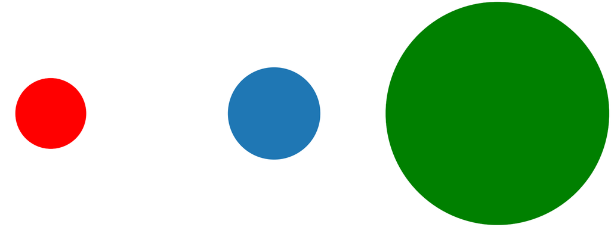

```
Guess 1- 1.75
```

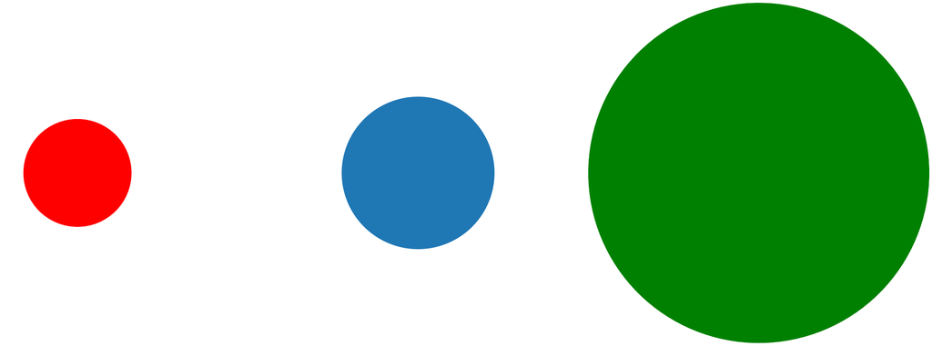

```
Guess 2- 1.95
```

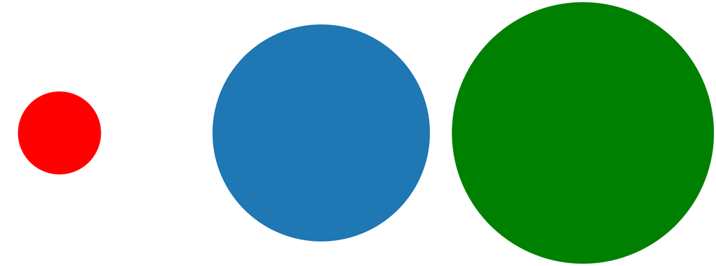

```
Guess 3- 7
```

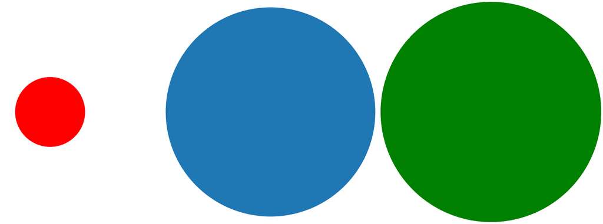

```
Guess 4- 8.75
```

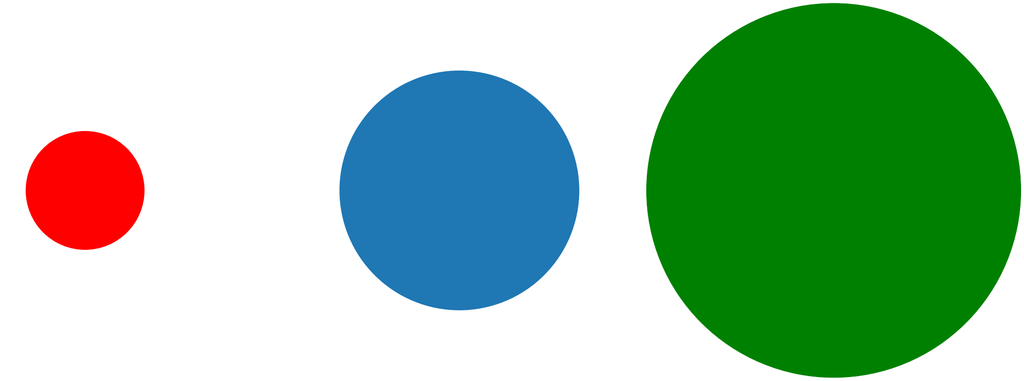

```
Guess 5- 4
```

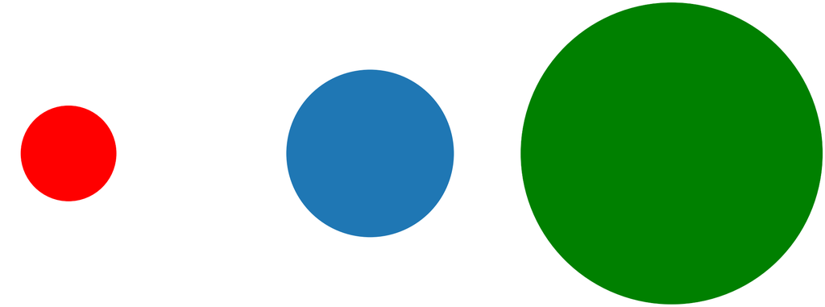

```
Guess 6- 3
```

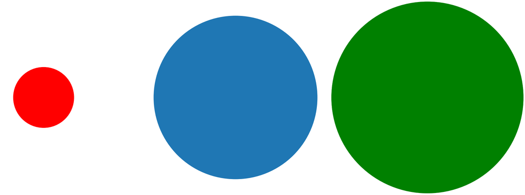

```
Guess 7- 7.25
```

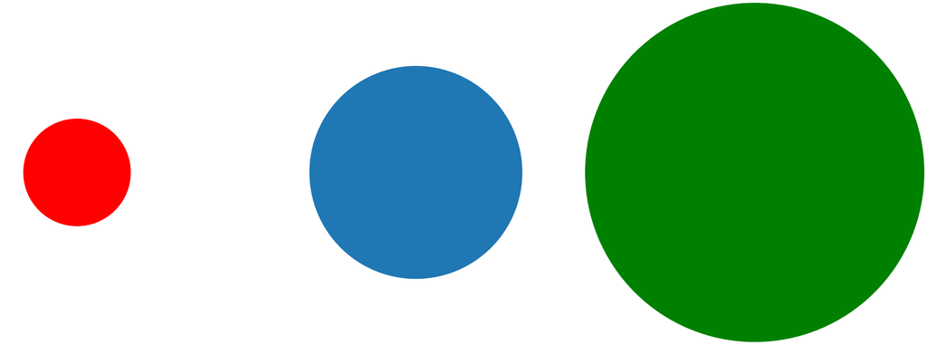

```
Guess 8- 3.75
```

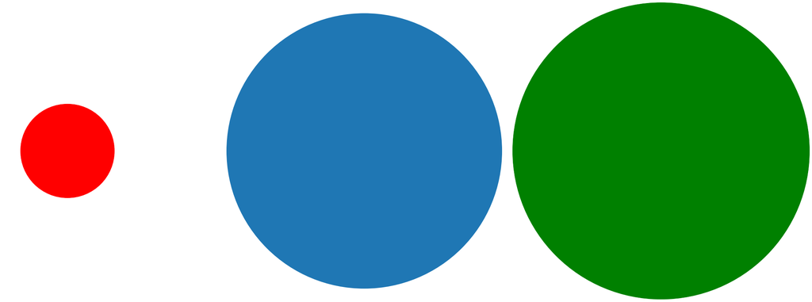

```
Guess 9- 9.25
```

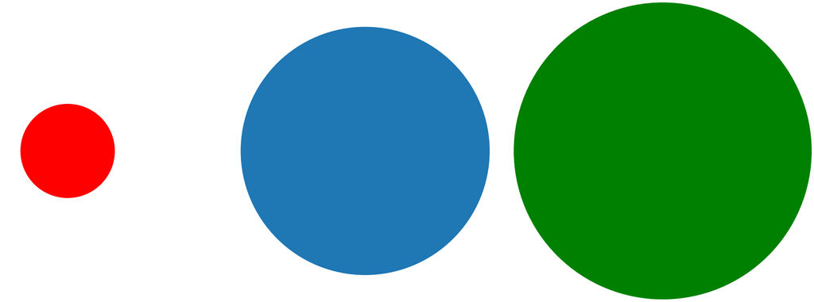

```
Guess 10- 7.75
```

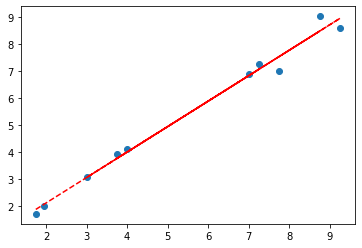

```python
perceived_area_list = []
actual_area_list = []
def run_area_exp(n1=0.005, n2=0.05):
    print('Guess the area of the blue circle')

    for i in range(1,11):

        radius1 = np.sqrt(n1/np.pi) # area = pi * r * r
        radius2 = np.sqrt(n2/np.pi)

        mystery_number = random.uniform(1,10)
        random_radius = np.sqrt(n1*mystery_number/math.pi)

        plt.axis('equal')
        plt.axis('off')

        #if i>5:

        circ1 = plt.Circle((0,0), radius1,clip_on=False,color='red')
        circ2 = plt.Circle((4*radius2,0),radius2,clip_on=False,color='green')
        #else:
        #    circ1 = plt.Circle((0,0), radius1,clip_on=False)
        #    circ2 = plt.Circle((4*radius2,0),radius2,clip_on=False)


        rand_circ = plt.Circle((2*radius2,0), random_radius, clip_on=False )
        plt.gca().add_artist(circ1)
        plt.gca().add_artist(circ2)
        plt.gca().add_artist(rand_circ)
        plt.show()

        perceived_area_list.append( float(input(f'Guess {i}- ')) )
        actual_area_list.append(mystery_number)

run_area_exp()
plt.scatter(x=perceived_area_list, y=actual_area_list)
x = perceived_area_list
y = actual_area_list
z = np.polyfit(x, y, 1)
p = np.poly1d(z)

plt.plot(x,p(x),"r--")

plt.show()
```

### Mix of different and same colored circles.

```
Guess the area of the blue circle
```

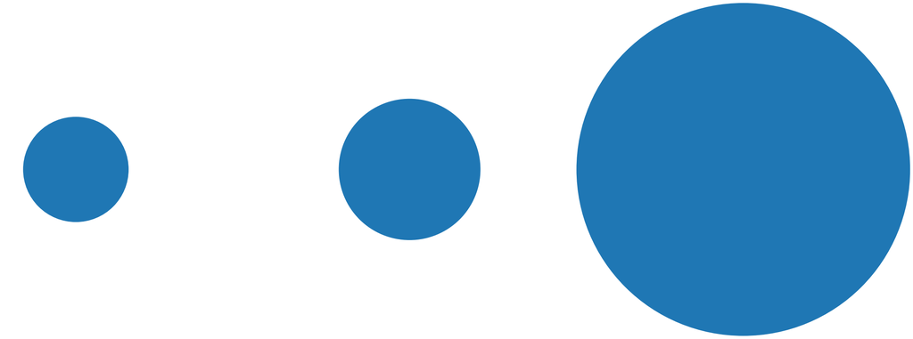

```
Guess 1- 2
```

[figure not shown]

```
Guess 2- 9
```

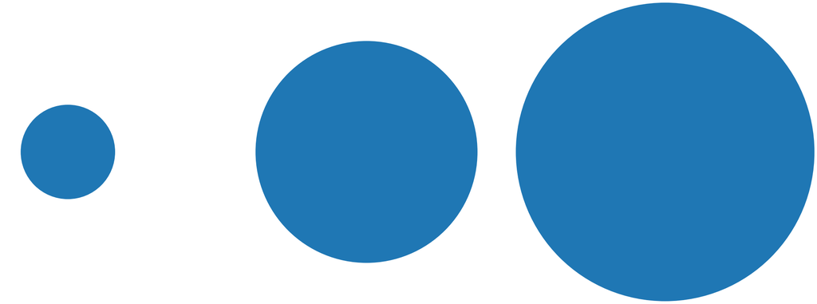

```
Guess 3- 6
```

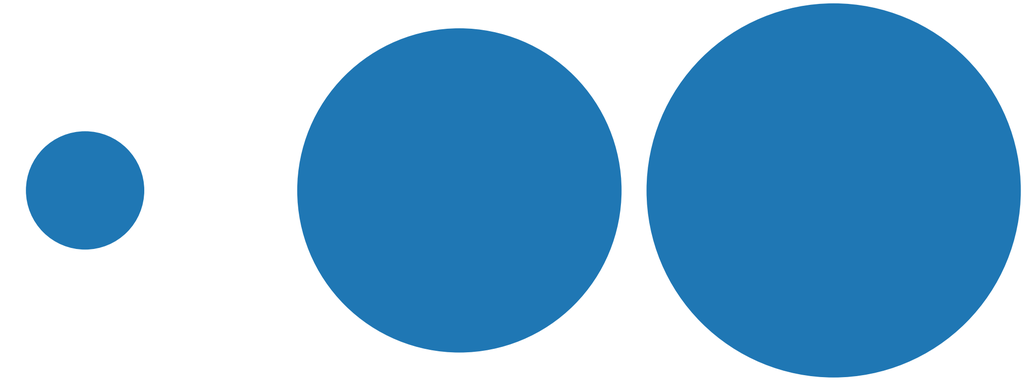

```
Guess 4- 7
```

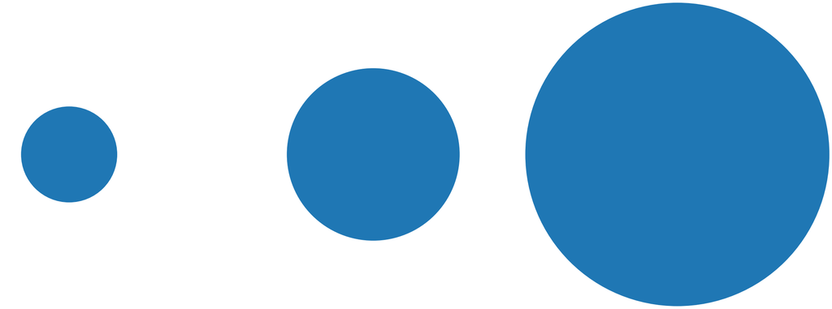

```
Guess 5- 3
```

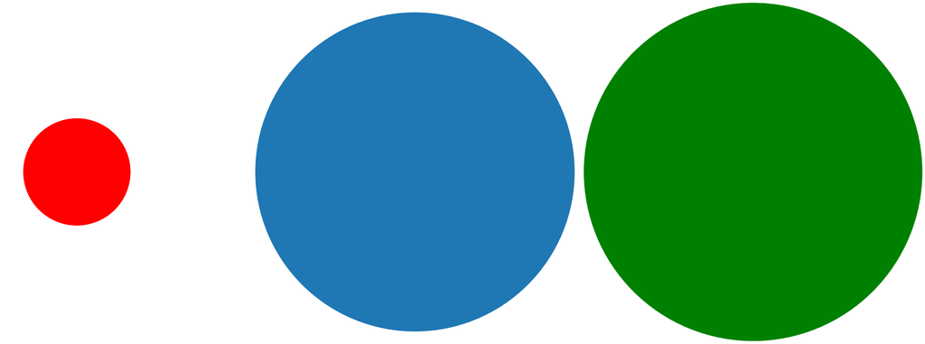

```
Guess 6- 8.25
```

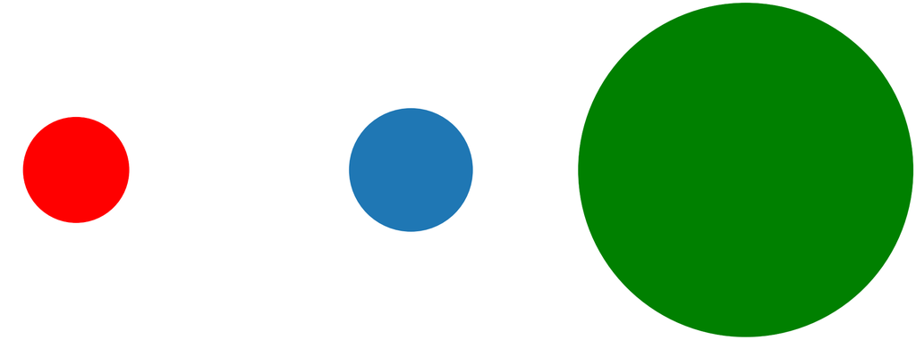

```
Guess 7- 1.5
```

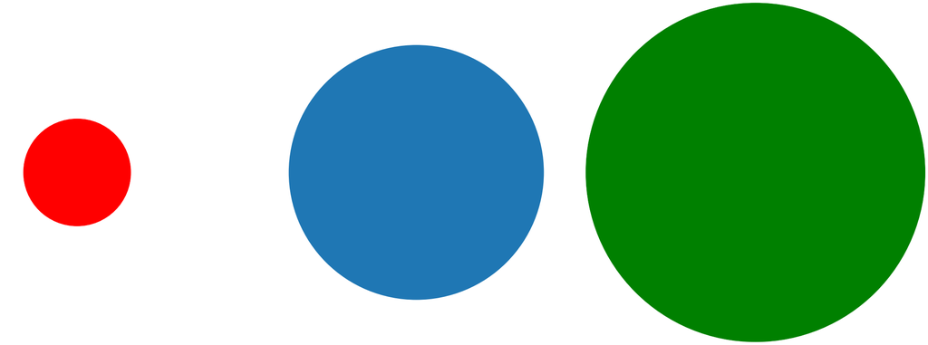

```
Guess 8- 5.6
```

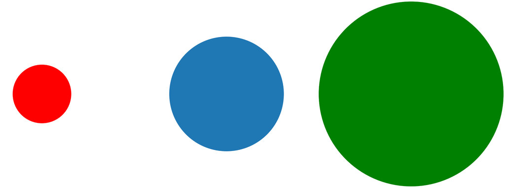

```
Guess 9- 4.25
```

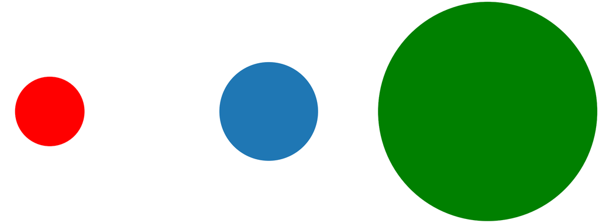

```
Guess 10- 2.25
```

```python
perceived_area_list = []
actual_area_list = []
def run_area_exp_once(n1=0.005, n2=0.05):
    print('Guess the area of the blue circle')

    for i in range(1,11):

        radius1 = np.sqrt(n1/np.pi) # area = pi * r * r
        radius2 = np.sqrt(n2/np.pi)

        mystery_number = random.uniform(1,10)
        random_radius = np.sqrt(n1*mystery_number/math.pi)

        plt.axis('equal')
        plt.axis('off')

        if i>5:

            circ1 = plt.Circle((0,0), radius1,clip_on=False,color='red')
            circ2 = plt.Circle((4*radius2,0),radius2,clip_on=False,color='green')
        else:
            circ1 = plt.Circle((0,0), radius1,clip_on=False)
            circ2 = plt.Circle((4*radius2,0),radius2,clip_on=False)


        rand_circ = plt.Circle((2*radius2,0), random_radius, clip_on=False )
        plt.gca().add_artist(circ1)
        plt.gca().add_artist(circ2)
        plt.gca().add_artist(rand_circ)
        plt.show()

        perceived_area_list.append( float(input(f'Guess {i}- ')) )
        actual_area_list.append(mystery_number)

run_area_exp_once()
```

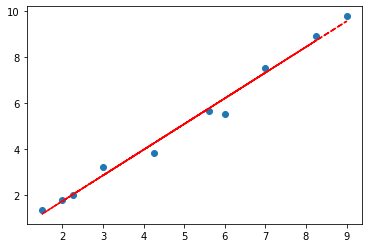

```python
plt.scatter(x=perceived_area_list, y=actual_area_list)
x = perceived_area_list
y = actual_area_list
z = np.polyfit(x, y, 1)
p = np.poly1d(z)

plt.plot(x,p(x),"r--")

plt.show()
```

## Task 5. Describe and interpret your results.

#### Results:

**1) Perception of length:** I did fairly well in this experiment- almost all of my predictions were close to the actual length of the mystery bar. Even the linear model used to fit my predictions with the actual lengths, does a decent job. This is consistent with revelations in previous psychophysical research that people tend to correctly estimate lengths.

**Reference:** https://makingmaps.net/2007/08/28/perceptual-scaling-of-map-symbols/

**Reference:** https://makingmaps.net/2007/08/28/perceptual-scaling-of-map-symbols/

Empirical results of research studies show that people in general correctly estimate lengths, but they struggle and understimate areas and volumes. Visualizations which include proportionally scaled circles have been the primary focus of many pyschophysical research studies which conclude that there is an inherent bias which leads to underestimating the areas and volumes. One research study suggests to use perceptual scaling to offset the underestimation. But, many scholars like, Tufte, have rejected the benefits of perceptual scaling. The concensus is that perceptual problem is not as evident in visualizations with a smaller range of circle sizes.

Visualizations which use proportionally scaled circles are quite common, and more recently the technique is used in many COVID trackers. One way they the handle perceptual problem is by using sequential palattes for indicating the density of cases in each area.

**Reference:** https://www.csc2.ncsu.edu/faculty/healey/PP/